# Project Python Foundations: FoodHub Data Analysis

### Context

The number of restaurants in New York is increasing day by day. Lots of students and busy professionals rely on those restaurants due to their hectic lifestyles. Online food delivery service is a great option for them. It provides them with good food from their favorite restaurants. A food aggregator company FoodHub offers access to multiple restaurants through a single smartphone app.

The app allows the restaurants to receive a direct online order from a customer. The app assigns a delivery person from the company to pick up the order after it is confirmed by the restaurant. The delivery person then uses the map to reach the restaurant and waits for the food package. Once the food package is handed over to the delivery person, he/she confirms the pick-up in the app and travels to the customer's location to deliver the food. The delivery person confirms the drop-off in the app after delivering the food package to the customer. The customer can rate the order in the app. The food aggregator earns money by collecting a fixed margin of the delivery order from the restaurants.

### Objective

The food aggregator company has stored the data of the different orders made by the registered customers in their online portal. They want to analyze the data to get a fair idea about the demand of different restaurants which will help them in enhancing their customer experience. Suppose you are hired as a Data Scientist in this company and the Data Science team has shared some of the key questions that need to be answered. Perform the data analysis to find answers to these questions that will help the company to improve the business.

### Data Description

The data contains the different data related to a food order. The detailed data dictionary is given below.

### Data Dictionary

- order_id: Unique ID of the order
- customer_id: ID of the customer who ordered the food
- restaurant_name: Name of the restaurant
- cuisine_type: Cuisine ordered by the customer
- cost_of_the_order: Cost of the order
- day_of_the_week: Indicates whether the order is placed on a weekday or weekend (The weekday is from Monday to Friday and the weekend is Saturday and Sunday)
- rating: Rating given by the customer out of 5
- food_preparation_time: Time (in minutes) taken by the restaurant to prepare the food. This is calculated by taking the difference between the timestamps of the restaurant's order confirmation and the delivery person's pick-up confirmation.
- delivery_time: Time (in minutes) taken by the delivery person to deliver the food package. This is calculated by taking the difference between the timestamps of the delivery person's pick-up confirmation and drop-off information

### Let us start by importing the required libraries

```python
# Installing the libraries with the specified version.
!pip install pandas==2.2.2 numpy==2.0.2 matplotlib==3.10.0 seaborn==0.13.2 scikit-learn==1.6.1 xgboost==2.1.4 -q --user
```

```python
# Installing plotly library for building beautiful and interactive visualizations
!pip install plotly
```

**Note**:

- After running the above cell, kindly restart the runtime (for Google Colab) or notebook kernel (for Jupyter Notebook), and run all cells sequentially from the next cell.
- On executing the above line of code, you might see a warning regarding package dependencies. This error message can be ignored as the above code ensures that all necessary libraries and their dependencies are maintained to successfully execute the code in **this notebook**.

```python
# import libraries for data manipulation
import numpy as np
import pandas as pd

# import libraries for data visualization
import matplotlib.pyplot as plt
import seaborn as sns
import plotly.express as px
import plotly.io as pio
pio.renderers.default = "colab"
%matplotlib inline
import plotly
plotly.offline.init_notebook_mode(connected=True)
```

### Understanding the structure of the data

```python
# uncomment and run the below code snippets if the dataset is present in the Google Drive
from google.colab import drive
drive.mount('/content/drive')
# uncomment and run the below code snippets if the dataset is present in the computer
#from google.colab import files
#uploaded = files.upload()
```

```python
# Write your code here to read the data from google drive
data = pd.read_csv("/content/drive/MyDrive/Colab Notebooks/foodhub_order.csv")

# loading data into a pandas dataframe from computer upload
#import io
#data = pd.read_csv(io.BytesIO(uploaded["foodhub_order.csv"]))
```

```python
# Write your code here to view the first 5 rows
# Returns the first 5 rows
data.head()
```

|  | order_id | customer_id | restaurant_name | cuisine_type | cost_of_the_order | day_of_the_week | rating | food_preparation_time | delivery_time |
| --- | --- | --- | --- | --- | --- | --- | --- | --- | --- |
| 0 | 1477147 | 337525 | Hangawi | Korean | 30.75 | Weekend | Not given | 25 | 20 |
| 1 | 1477685 | 358141 | Blue Ribbon Sushi Izakaya | Japanese | 12.08 | Weekend | Not given | 25 | 23 |
| 2 | 1477070 | 66393 | Cafe Habana | Mexican | 12.23 | Weekday | 5 | 23 | 28 |
| 3 | 1477334 | 106968 | Blue Ribbon Fried Chicken | American | 29.20 | Weekend | 3 | 25 | 15 |
| 4 | 1478249 | 76942 | Dirty Bird to Go | American | 11.59 | Weekday | 4 | 25 | 24 |

### **Question 1:** How many rows and columns are present in the data? [0.5 mark]

```python
# Write your code here
# Check the shape of the dataset
data.shape
```

```
(1898, 9)
```

#### Observations:The dataset has 1898 rows and 9 columns.

### **Question 2:** What are the datatypes of the different columns in the dataset? (The info() function can be used) [0.5 mark]

```python
# Write your code here
data.info()
```

```
<class 'pandas.core.frame.DataFrame'>
RangeIndex: 1898 entries, 0 to 1897
Data columns (total 9 columns):
 #   Column                 Non-Null Count  Dtype
---  ------                 --------------  -----
 0   order_id               1898 non-null   int64
 1   customer_id            1898 non-null   int64
 2   restaurant_name        1898 non-null   object
 3   cuisine_type           1898 non-null   object
 4   cost_of_the_order      1898 non-null   float64
 5   day_of_the_week        1898 non-null   object
 6   rating                 1898 non-null   object
 7   food_preparation_time  1898 non-null   int64
 8   delivery_time          1898 non-null   int64
dtypes: float64(1), int64(4), object(4)
memory usage: 133.6+ KB
```

### **Question 3:** Are there any missing values in the data? If yes, treat them using an appropriate method. [1 mark]

```python
# Write your code here
# Appropriate function to print the sum of null values for each column
data.isnull().sum()
```

|  | 0 |
| --- | --- |
| order_id | 0 |
| customer_id | 0 |
| restaurant_name | 0 |
| cuisine_type | 0 |
| cost_of_the_order | 0 |
| day_of_the_week | 0 |
| rating | 0 |
| food_preparation_time | 0 |
| delivery_time | 0 |

**dtype:** int64

```python
data.isnull().sum().sum()
```

```
np.int64(0)
```

```python
# checking for duplicate values
data.duplicated().sum()
```

```
np.int64(0)
```

#### Observations: There are no null values in order id, customer id,restaurant name, cuisine type, cost of the order,day of the week, food preparation time, delivery time and rating.

### **Question 4:** Check the statistical summary of the data. What is the minimum, average, and maximum time it takes for food to be prepared once an order is placed? [2 marks]

```python
# Write your code here
# Get the summary statistics of the numerical data
data.describe(include='all').T
```

|  | count | unique | top | freq | mean | std | min | 25% | 50% | 75% | max |
| --- | --- | --- | --- | --- | --- | --- | --- | --- | --- | --- | --- |
| order_id | 1898.0 | NaN | NaN | NaN | 1477495.5 | 548.049724 | 1476547.0 | 1477021.25 | 1477495.5 | 1477969.75 | 1478444.0 |
| customer_id | 1898.0 | NaN | NaN | NaN | 171168.478398 | 113698.139743 | 1311.0 | 77787.75 | 128600.0 | 270525.0 | 405334.0 |
| restaurant_name | 1898 | 178 | Shake Shack | 219 | NaN | NaN | NaN | NaN | NaN | NaN | NaN |
| cuisine_type | 1898 | 14 | American | 584 | NaN | NaN | NaN | NaN | NaN | NaN | NaN |
| cost_of_the_order | 1898.0 | NaN | NaN | NaN | 16.498851 | 7.483812 | 4.47 | 12.08 | 14.14 | 22.2975 | 35.41 |
| day_of_the_week | 1898 | 2 | Weekend | 1351 | NaN | NaN | NaN | NaN | NaN | NaN | NaN |
| rating | 1898 | 4 | Not given | 736 | NaN | NaN | NaN | NaN | NaN | NaN | NaN |
| food_preparation_time | 1898.0 | NaN | NaN | NaN | 27.37197 | 4.632481 | 20.0 | 23.0 | 27.0 | 31.0 | 35.0 |
| delivery_time | 1898.0 | NaN | NaN | NaN | 24.161749 | 4.972637 | 15.0 | 20.0 | 25.0 | 28.0 | 33.0 |

### **Question 5:** How many orders are not rated? [1 mark]

```python
# Write the code here
data['rating'].value_counts() #get the number of different values
```

| rating | count |
| --- | --- |
| Not given | 736 |
| 5 | 588 |
| 4 | 386 |
| 3 | 188 |

**dtype:** int64

```python
data['rating'].unique() #get the different values
```

```
array(['Not given', '5', '3', '4'], dtype=object)
```

#### Observations: orders which are not rated is 736, maximum ratings are 5 and minimum ratings are 3. We can see that there are mixed data type values in the column like - 'Not given'.

### Exploratory Data Analysis (EDA)

### **Question 6:** Explore all the variables and provide observations on their distributions. (Generally, histograms, boxplots, countplots, etc. are used for univariate exploration.) [9 marks]

```python
#unique values for order ID
data['order_id'].nunique()
```

```
1898
```

```python
#unique values for customer ID
data['customer_id'].nunique()
```

```
1200
```

```python
#unique values for restaurnat names
data['restaurant_name'].nunique()
```

```
178
```

```python
data['restaurant_name'].value_counts()
```

| restaurant_name | count |
| --- | --- |
| Shake Shack | 219 |
| The Meatball Shop | 132 |
| Blue Ribbon Sushi | 119 |
| Blue Ribbon Fried Chicken | 96 |
| Parm | 68 |
| ... | ... |
| Rye House | 1 |
| Hiroko's Place | 1 |
| Frank Restaurant | 1 |
| Sarabeth's West | 1 |
| 'wichcraft | 1 |

178 rows × 1 columns

**dtype:** int64

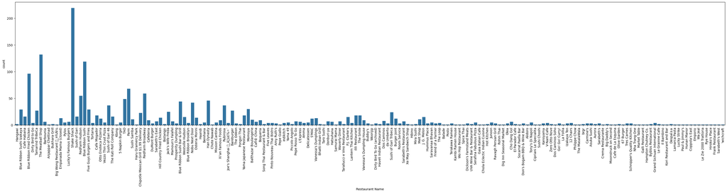

```python
#Countplot for restaurant name
plt.figure(figsize = (40,7))
sns.countplot(data = data, x = 'restaurant_name');
plt.xticks(rotation = 90)
plt.xlabel('Restaurant Name')
```

Observations: Orders came from shake and shack is higher.

```python
#unique values for Cuisine types
data['cuisine_type'].nunique()
```

```
14
```

```python
data['cuisine_type'].value_counts()
```

| cuisine_type | count |
| --- | --- |
| American | 584 |
| Japanese | 470 |
| Italian | 298 |
| Chinese | 215 |
| Mexican | 77 |
| Indian | 73 |
| Middle Eastern | 49 |
| Mediterranean | 46 |
| Thai | 19 |
| French | 18 |
| Southern | 17 |
| Korean | 13 |
| Spanish | 12 |
| Vietnamese | 7 |

**dtype:** int64

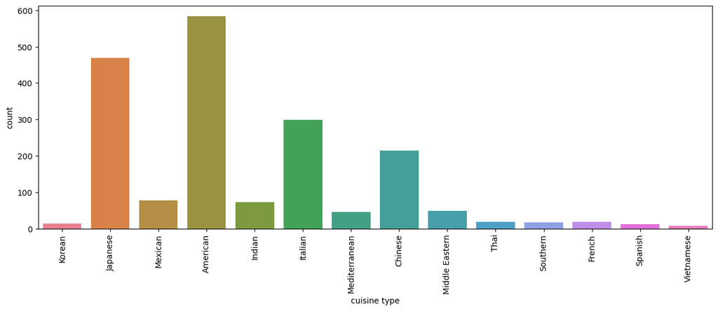

```python
plt.figure(figsize = (15,5))
sns.countplot(data = data, x = 'cuisine_type', hue='cuisine_type') #Countplot for cuisine type
plt.xticks(rotation = 90)
plt.xlabel('cuisine type')
plt.show()
```

Observations: American cuisine type has more orders than Japanese and with lowest orders have vietnamese

```python
#Histogram for the cost of order
cost=px.histogram(data,x='cost_of_the_order')
cost.show()
```

[interactive chart not shown]

```python
# Boxplot for the cost of order
cost_in_box=px.box(data,x='cost_of_the_order')
cost_in_box.show()
```

[interactive chart not shown]

Observations: Cost of the order is positively right skewed with no outliers and median is 14.14$ with Q1 at 12.08 and Q3 at 22.31 dollars which is 50%, 25% is between 4.47 to 12.08 dollars and 25% is between 22.31 to 35.41 dollars

```python
#unique values for day of the week
data['day_of_the_week'].nunique()
```

```
2
```

```python
data['day_of_the_week'].value_counts()
```

| day_of_the_week | count |
| --- | --- |
| Weekend | 1351 |
| Weekday | 547 |

**dtype:** int64

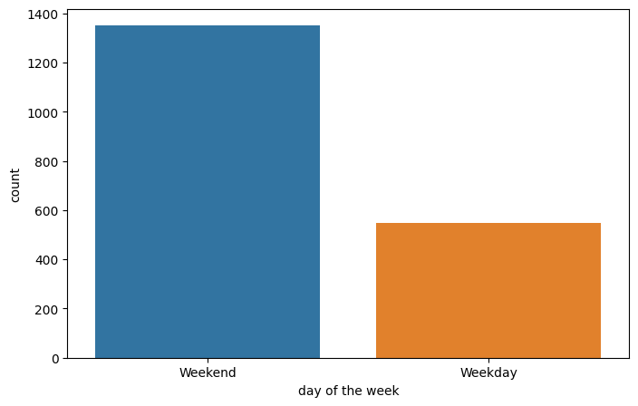

```python
# plot a bar graph for 'day_of_the_week'
plt.figure(figsize = (8,5))
sns.countplot(data = data, x ='day_of_the_week', hue='day_of_the_week')
plt.xlabel('day of the week')
plt.show()
```

Observations: orders on weekend are more than orders in weekday

```python
#unique values for ratings
data['rating'].nunique()
```

```
4
```

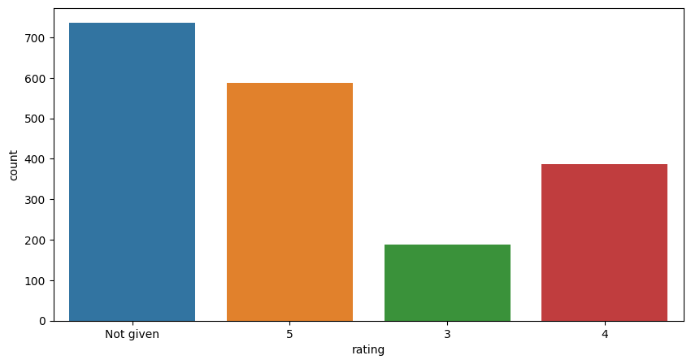

```python
# plot a bar graph for ratings.
plt.figure(figsize = (10,5))
sns.countplot(data, x ='rating', hue = 'rating')
plt.show()
```

```python
#unique values for food preparation time
data['food_preparation_time'].nunique()
```

```
16
```

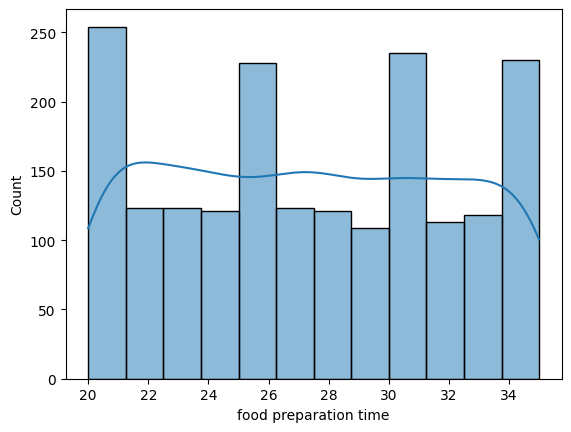

```python
#Histogram for the food preparation time
sns.histplot(data=data,x='food_preparation_time',kde=True)
plt.xlabel('food preparation time')
plt.show()
```

```python
# Boxplot for the food preparation time
prepare_time=px.box(data,x='food_preparation_time')
prepare_time.show()
```

[interactive chart not shown]

Observations: it is slightly looks like a normal distribution but it is right skewed with median at 27 minutes, Q1 at 23 minutes, Q2 at 31 minutes. with 50% of orders ranges from 23 min to 31 min. There are no outliers. The minimum time for food preparation is 20 minutes and maximum time for preparation is 35 minutes

```python
#unique values for delivery time
data['delivery_time'].nunique()
```

```
19
```

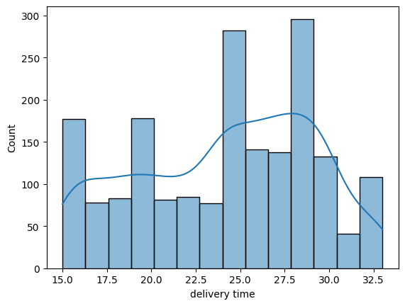

```python
#Histogram for the delivery time
sns.histplot(data=data,x='delivery_time',kde=True)
plt.xlabel('delivery time')
plt.show()
```

```python
# Boxplot for the delivery time
delivery_time=px.box(data,x='delivery_time')
delivery_time.show()
```

[interactive chart not shown]

Observations: delivery time is left skewed with median as 25 minutes. with Q1 as 20 minutes and Q2 has 28 minutes which is 50% of orders ranges between 20-28 minutes. There are no outliers. Minimum time for delivery is 15 minutes and maximum time for delivery is 33 minutes

### **Question 7**: Which are the top 5 restaurants in terms of the number of orders received? [1 mark]

```python
# Write the code here
# Top 5 restaurants in terms of the number of orders received
data['restaurant_name'].value_counts().head(5)
```

| restaurant_name | count |
| --- | --- |
| Shake Shack | 219 |
| The Meatball Shop | 132 |
| Blue Ribbon Sushi | 119 |
| Blue Ribbon Fried Chicken | 96 |
| Parm | 68 |

**dtype:** int64

#### Observations: Shake Shack, The Meatball shop, Blue Ribbon Sushi, Blue Ribbon Fried Chicken and Parm are top 5 restaurants for orders with 219, 132, 119, 96 and 68 respectively.

### **Question 8**: Which is the most popular cuisine on weekends? [1 mark]

```python
# Write the code here
# Most popular cuisine on weekends
data[data['day_of_the_week'] == 'Weekend']['cuisine_type'].value_counts().head(1)
```

| cuisine_type | count |
| --- | --- |
| American | 415 |

**dtype:** int64

#### Observations: American is most popular cusine on weekends with 415 orders

### **Question 9**: What percentage of the orders cost more than 20 dollars? [2 marks]

```python
# Write the code here
#The number of total orders where the cost is above 20 dollars
print('Total number of orders that cost more than 20 dollars:', data[data['cost_of_the_order']>20].shape[0])

# percentage of such orders in the dataset
percentage = (data[data['cost_of_the_order']>20].shape[0] / data.shape[0]) * 100

print("Percentage of orders cost more than 20 dollars:", round(percentage, 2), '%')
```

```
Total number of orders that cost more than 20 dollars: 555
Percentage of orders cost more than 20 dollars: 29.24 %
```

#### Observations:

Total number of orders that cost more than 20 dollars are 555 and percentage of orders cost more than 20 dollars is 29.24 %

### **Question 10**: What is the mean order delivery time? [1 mark]

```python
# Write the code here
# mean delivery time
print('The mean order delivery time is', round(data['delivery_time'].mean(), 2), 'minutes')
```

```
The mean order delivery time is 24.16 minutes
```

#### Observations:The mean order delivery time is 24.16 minutes

### **Question 11:** The company has decided to give 20% discount vouchers to the top 3 most frequent customers. Find the IDs of these customers and the number of orders they placed. [1 mark]

```python
# Write the code here
# Top 3 most frequent customers IDs and the number of orders they placed
data['customer_id'].value_counts().head(3)
```

| customer_id | count |
| --- | --- |
| 52832 | 13 |
| 47440 | 10 |
| 83287 | 9 |

**dtype:** int64

#### Observations: Top 3 most frequent customers IDs and the number of orders they placed are 52832 with 13 orders, 47440 with 10 orders and 83287 with 9 orders

### **Question 12**: Perform a multivariate analysis to explore relationships between the important variables in the dataset. (It is a good idea to explore relations between numerical variables as well as relations between numerical and categorical variables) [10 marks]

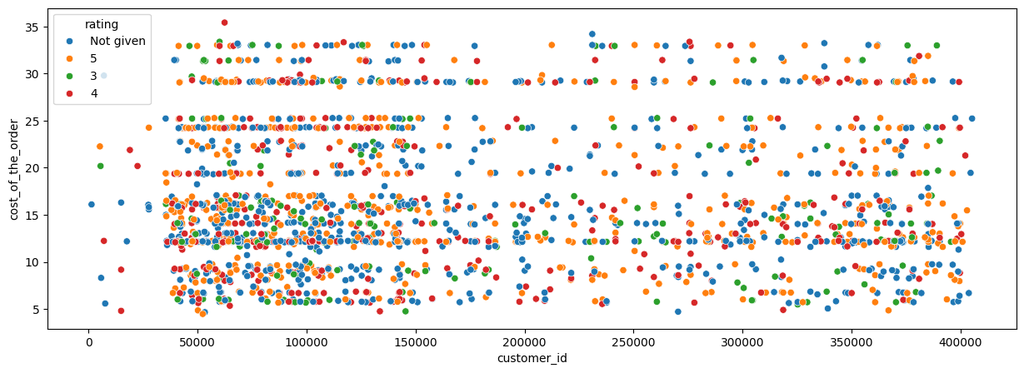

```python
# Relationship between cost of the order and customer_id
plt.figure(figsize=(15,5))
sns.scatterplot(data = data, x = "customer_id", y = "cost_of_the_order", hue='rating')
plt.show()
```

```python
revenue=data.groupby(['restaurant_name'])['cost_of_the_order'].sum().sort_values(ascending = False)
revenue
```

| restaurant_name | cost_of_the_order |
| --- | --- |
| Shake Shack | 3579.53 |
| The Meatball Shop | 2145.21 |
| Blue Ribbon Sushi | 1903.95 |
| Blue Ribbon Fried Chicken | 1662.29 |
| Parm | 1112.76 |
| ... | ... |
| Market Table | 6.79 |
| Wa Jeal | 6.74 |
| Big Wong Restaurant _¤¾Ñ¼ | 5.92 |
| Cipriani Le Specialita | 5.92 |
| Hunan Manor | 5.72 |

178 rows × 1 columns

**dtype:** float64

Observations: Customers between 50000 to 150000 spend more between 5 to 15 dollars for cost of order. With more number of ratings as not given. shake shack has highest revenue of cost 3579.53 dollars and Hunan Manor has lowest revenue of 5.72 dollars.

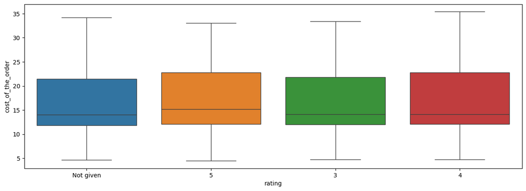

```python
# Relationship between rating and cost of the order
plt.figure(figsize=(15, 5))
sns.boxplot(data = data,x = 'rating', y = 'cost_of_the_order', hue='rating')
plt.show()
```

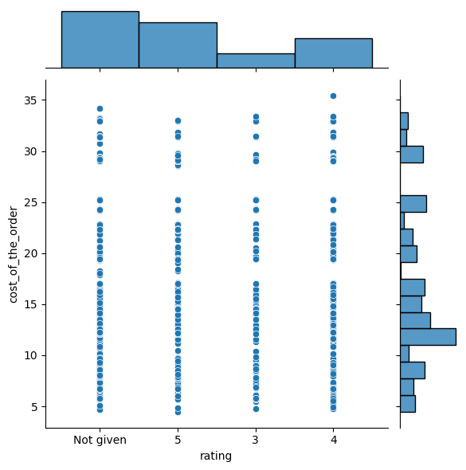

```python
plt.figure(figsize=(15, 5))
sns.jointplot(data = data, x = 'rating', y = 'cost_of_the_order')
plt.show()
```

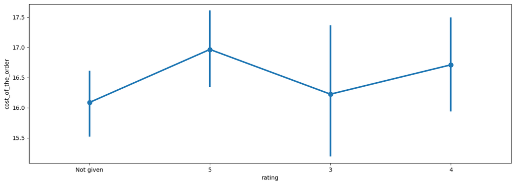

```python
plt.figure(figsize=(15, 5))
sns.pointplot(data = data, x = 'rating', y = 'cost_of_the_order')
plt.show()
```

```python
# Relationship between cuisine type and cost of the order
cus=px.box(data, x = "cuisine_type", y = "cost_of_the_order", color='cuisine_type')
cus.show()
```

[interactive chart not shown]

Observations: Spanich cuisine has highest minimum cost of order value of 12.13 dollars and lowest minimum cost of order value is 4.47 dollars. Vietnamese as lowest median as 12.13$ cost of order whereas French cuisine has highest median of 20.47 dollars as cost of order. chinese cuisine has highest maximum cost of order is 34.19 dollars and Korean cuisine has lowest upper fence as 14.07 dollars as cost but lowest minimum cost is 22.26 of vietnamese cuisine. Southern cuisine has highest interval in cost. All cuisines are right skewed. Korean and mediterranean cuisines have both outliers on the rightside but Korean cuisine has left outliers.

```python
# Relationship between cuisine type and food preparation time
food=px.box(data, x = "cuisine_type", y = "food_preparation_time", color = "cuisine_type")
food.show()
```

[interactive chart not shown]

Observations: Thai and French cuisines has highest minimum preparation time than other cuisines with 21 minutes, Korean and Vietnamese has lowest maximum preparation time with 33 minutes. There are no outliers,Thai cuisine has highest 50% allocated for food preparation with highest median 28 minutes along with Italian. Korean and Vietnamese has lowest median of 25 minutes.

```python
# Relationship between cuisine type and delivery time
food_del=px.box(data, x = "cuisine_type", y = "delivery_time", color = "cuisine_type")
food_del.show()
```

[interactive chart not shown]

Observations: Vietnames cuisine has highest minimum delivery time than other cuisines with 19 minutes, Korean has lowest maximum delivery time with 26 minutes. There are no outliers,Middle Eastern and Mediterranean cuisines has highest 50% allocated for food delivery.French cuisine with highest median 27 minutes. Korean has lowest median of 20 minutes.

```python
# Relationship between rating and food_preparation_time
prepare_time=px.box(data, x ="rating", y = "food_preparation_time", color='rating')
prepare_time.show()
```

[interactive chart not shown]

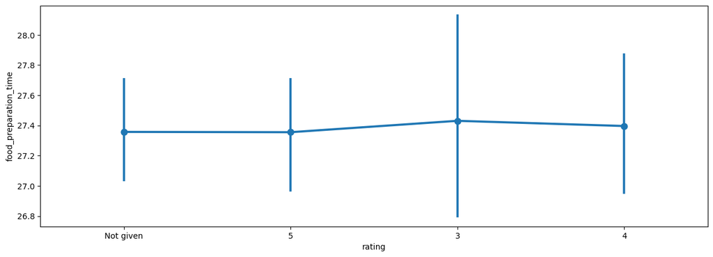

```python
plt.figure(figsize=(15, 5))
sns.pointplot(data = data, x = 'rating', y = 'food_preparation_time')
plt.show()
```

Observations: Rating 5,3,4 have same number of minutes for food preparation time. Rating 3 has highest confidence inteval ranges from 26 min to above 28 min of food preparation.

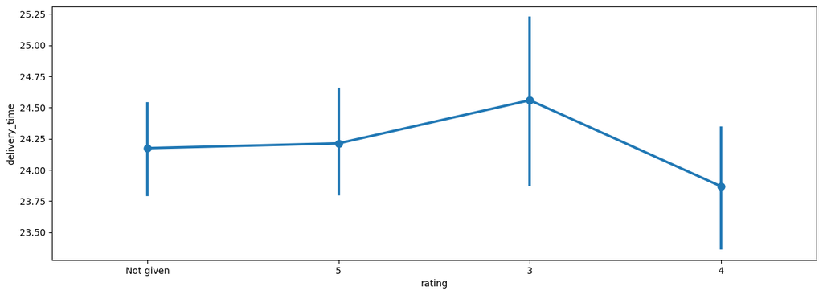

```python
# Relationship between rating and delivery_time
plt.figure(figsize=(15, 5))
sns.pointplot(data = data, x = 'rating', y = 'delivery_time')
plt.show()
```

```python
del_time=px.box(data, x ="rating", y = "delivery_time", color='rating')
del_time.show()
```

[interactive chart not shown]

Observations: rating 3 has highest confidence of interval for delivery time

```python
# Relationship between day of the week and delivery time
days=px.box(data, x = "day_of_the_week", y = "delivery_time", color = "day_of_the_week")
days.show()
```

[interactive chart not shown]

Observation:Weekend is use less delivery time than weekday. Both are positively right skewed.

```python
# Relationship between day of the week and food preparation time
days_week=px.box(data, x = "day_of_the_week", y = "food_preparation_time", color = "day_of_the_week")
days_week.show()
```

[interactive chart not shown]

Observations: food preparation time doesn't differ with weekend and weekday

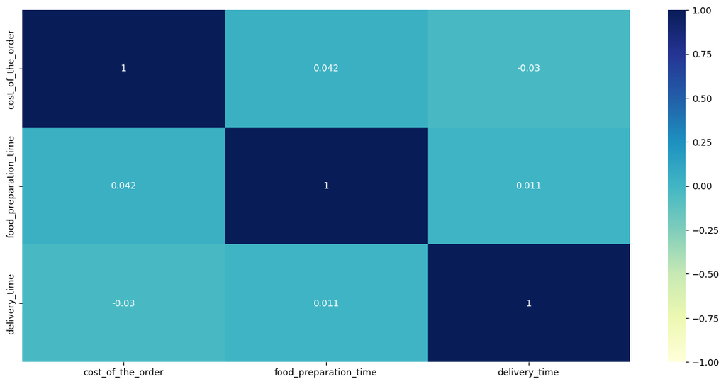

```python
#heatmap for cost of the order, food preparation time and delivery time
plt.figure(figsize=(15, 7))
sns.heatmap(data[['cost_of_the_order', 'food_preparation_time', 'delivery_time']].corr(), annot=True, vmin=-1, vmax=1, cmap="YlGnBu")
plt.show()
```

### **Question 13:** The company wants to provide a promotional offer in the advertisement of the restaurants. The condition to get the offer is that the restaurants must have a rating count of more than 50 and the average rating should be greater than 4. Find the restaurants fulfilling the criteria to get the promotional offer. [3 marks]

```python
# Write the code here
#create the copy for removing not given values
num_rated= data[data['rating']!= 'Not given'].copy()
num_rated['rating'] = num_rated['rating'].astype('int') #convert to rating column to integer
# Restaurants fulfilling the criteria to get the promotional offer by using groupby
rated_group=num_rated.groupby(['restaurant_name'])['rating'].count().sort_values(ascending = False).reset_index()
#print(rated_group)
#Restaurants that have rating count more than 50
rated_group_50 = rated_group[rated_group['rating']>50]['restaurant_name']
mean_rated = num_rated[num_rated['restaurant_name'].isin(rated_group_50)].copy()
#print(mean_rated)
# calculate mean of restaurants that have ratings
mean_rated_rest = mean_rated.groupby(['restaurant_name'])['rating'].mean().sort_values(ascending = False).reset_index()
#print(mean_rated_rest)
# get restaurants that have average rating greater than 4
mean_rated_rest_4 = mean_rated_rest[mean_rated_rest['rating'] > 4].sort_values(by='rating', ascending=False).reset_index(drop=True)
mean_rated_rest_4
```

|  | restaurant_name | rating |
| --- | --- | --- |
| 0 | The Meatball Shop | 4.511905 |
| 1 | Blue Ribbon Fried Chicken | 4.328125 |
| 2 | Shake Shack | 4.278195 |
| 3 | Blue Ribbon Sushi | 4.219178 |

#### Observations: The Meatball shop, Blue Ribbon Fried chicken, Shake Shack and Blue Ribbon Sushi are the restaurants fulfilling the criteria to get the promotional offer

### **Question 14:** The company charges the restaurant 25% on the orders having cost greater than 20 dollars and 15% on the orders having cost greater than 5 dollars. Find the net revenue generated by the company across all orders. [3 marks]

```python
# Write the code here
# restaurants give 25% on the orders having cost greater than 20 dollars and 15% on the orders having cost greater than 5 dollars by using lamda function
data['net'] = data['cost_of_the_order'].apply(lambda x: (x*0.25) if x > 20 else ((x*0.15) if x>5 else (x*0)))
# net revenue generated by the company across all orders
revenue = data['net'].sum()
print('The net revenue generated by the company across all orders:', round(revenue, 2), 'dollars')
```

```
The net revenue generated by the company across all orders: 6166.3 dollars
```

#### Observations: The net revenue generated by the company across all orders: 6166.3 dollars

### **Question 15:** The company wants to analyze the total time required to deliver the food. What percentage of orders take more than 60 minutes to get delivered from the time the order is placed? (The food has to be prepared and then delivered.) [2 marks]

```python
# Write the code here
# Calculate total time for delivery from the time the order is placed
data['total'] = data['food_preparation_time'] + data['delivery_time']
data.head()
```

|  | order_id | customer_id | restaurant_name | cuisine_type | cost_of_the_order | day_of_the_week | rating | food_preparation_time | delivery_time | net | total |
| --- | --- | --- | --- | --- | --- | --- | --- | --- | --- | --- | --- |
| 0 | 1477147 | 337525 | Hangawi | Korean | 30.75 | Weekend | Not given | 25 | 20 | 7.6875 | 45 |
| 1 | 1477685 | 358141 | Blue Ribbon Sushi Izakaya | Japanese | 12.08 | Weekend | Not given | 25 | 23 | 1.8120 | 48 |
| 2 | 1477070 | 66393 | Cafe Habana | Mexican | 12.23 | Weekday | 5 | 23 | 28 | 1.8345 | 51 |
| 3 | 1477334 | 106968 | Blue Ribbon Fried Chicken | American | 29.20 | Weekend | 3 | 25 | 15 | 7.3000 | 40 |
| 4 | 1478249 | 76942 | Dirty Bird to Go | American | 11.59 | Weekday | 4 | 25 | 24 | 1.7385 | 49 |

```python
#Percentage of orders that total time is above 60 minutes
percentage = ((data[data['total']>60].shape[0]) / data.shape[0]) * 100
print("Percentage of orders that total time is above 60 minutes:", round(percentage, 2), '%')
```

```
Percentage of orders that total time is above 60 minutes: 10.54 %
```

### **Question 16:** The company wants to analyze the delivery time of the orders on weekdays and weekends. How does the mean delivery time vary during weekdays and weekends? [2 marks]

```python
# Write the code here
# mean delivery time of the orders on weekdays
print('The mean delivery time on weekdays:',round(data[data['day_of_the_week'] == 'Weekday']['delivery_time'].mean()),'minutes')

# mean delivery time of the orders on weekends
print('The mean delivery time on weekends:', round(data[data['day_of_the_week'] == 'Weekend']['delivery_time'].mean()),'minutes')
```

```
The mean delivery time on weekdays: 28 minutes
The mean delivery time on weekends: 22 minutes
```

#### Observations:

The mean delivery time on weekdays: 28 minutes The mean delivery time on weekends: 22 minutes Based on above results the mean of delivery time is more on weekdays other than weekends.Number of orders placed on weekends is higher than weekdays results in less delivery time on weekends